# Steps for Cleaning Data

Vanuatu National Statistics Office

15 Jul 2020

## 0.1 Introduction

In this tutorial we’ll be learning about the steps involved in **cleaning** our data. These steps are also important so we can spot any problems with the data early and limit their impact on our analyses. We’ll be using the `mtcars` dataset in the current tutorial, this is a dataset that comes with every R installation. You can read more about these data [here](https://stat.ethz.ch/R-manual/R-devel/library/datasets/html/mtcars.html). The current tutorial was created using Rmarkdown - a powerful tool to help us create formatted using R code. If you’re interested in using Rmarkdown, there is a great tutorial [here](https://rmarkdown.rstudio.com/lesson-1.html).

## 0.2 Loading required libraries

The power of R is that millions of people are using it. R comes with a large set of `base` functions that we’ll be using. Sometimes though it is useful to using some additional libraries. When storing data I would always recommend storing them as `csv` formatted files. However, it is useful to be able to work with excel formatted files directly. We can install and load libraries with the following code to work with excel formatted files:

```r
install.packages("openxlsx") # We'll use this package to handle excel formatted spreadsheets
```

Once installed, load them with the following code:

```r
# Load the openxlsx library
library(openxlsx)
```

## 0.3 Setting the working directory

Next, we’ll set the working directory - usually the folder on our computer where we have stored our data. We can use the following code for this:

```r
# Note the path to the working directory
workingDirectory <- file.path("insert", "path", "to", "working", "directory", "here")

# Set the working directory
setwd(repositoryPath)
```

## 0.4 Importing the data

With our working directory set, we can now import some data. Today our data will be in `csv` (**C**omma, **S**eparated **V**alues) format, which is a standard format for storing a table in a simple text form.

Here is some code to read in a csv file:

```r
motorCarTrends <- read.csv(file.path("..", "data", "carInfo_27-05-20.csv"), header=TRUE)
```

Or we can use the following code to ask you to select a file:

```r
motorCarTrends <- read.csv(file.choose(), header=TRUE)
```

Additionally, if the data was in ‘xlsx’ format we would import by:

```r
# Read in the xlsx file
motorCarTrends <- read.xlsx(file.path("..", "data", "carInfo_27-05-20.xlsx"))
```

## 0.5 Exploring the data

### 0.5.1 A quick look

There are loads of functions that we can use in R to quickly explore our data. Making sure it is in the right format for our analyses down the line. It is can also be used to explore the underlying data for error detection.

```r
# Check out the names of the MotorCarTrends variable
names(motorCarTrends)
```

```
##  [1] "Id"    "model" "mpg"   "cyl"   "disp"  "hp"    "drat"  "wt"    "qsec"
## [10] "vs"    "am"    "gear"  "carb"
```

```r
# Check the class of the MotorCarTrends variable
class(motorCarTrends)
```

```
## [1] "data.frame"
```

```r
# Check the classes of each column in the MotorCarTrends dataframe
colClasses <- sapply(motorCarTrends, FUN=class)
print(colClasses)
```

```
##          Id       model         mpg         cyl        disp          hp
##   "integer" "character"   "numeric"   "integer"   "numeric"   "integer"
##        drat          wt        qsec          vs          am        gear
##   "numeric"   "numeric"   "numeric"   "integer"   "integer"   "integer"
##        carb
##   "integer"
```

```r
# Check the dimensions of the MotorCarTrends dataframe
dim(motorCarTrends)
```

```
## [1] 36 13
```

```r
# View the first 5 rows of the table
head(motorCarTrends, n=5)
```

```
##   Id   model  mpg cyl disp  hp drat    wt  qsec vs am gear carb
## 1  1  Mazda  21.0   6  160 110 3.90 2.620 16.46  0  1    4    4
## 2  2  Mazda  21.0   6  160 110 3.90 2.875 17.02  0  1    4    4
## 3  3 Datsun  22.8   4  108  93 3.85 2.320 18.61  1  1    4    1
## 4  4 Hornet  21.4   6  258 110 3.08 3.215 19.44  1  0    3    1
## 5  5 Hornet  18.7   8  360 175 3.15 3.440 17.02  0  0    3    2
```

```r
# View the last 5 rows of the table
tail(motorCarTrends, n=5)
```

```
##    Id    model  mpg cyl disp  hp drat   wt qsec vs am gear carb
## 32 30  Ferrari 19.7   6  145 175 3.62 2.77 15.5  0  1    5    6
## 33 30  Ferrari 19.7   6  145 175 3.62 2.77 15.5  0  1    5    6
## 34 30  Ferrari 19.7   6  145 175 3.62 2.77 15.5  0  1    5    6
## 35 31 Maserati 15.0   8  301 335 3.54 3.57 14.6  0  1    5    8
## 36 32    Volvo 21.4   4  121 109 4.11 2.78   NA  1  1    4    2
```

```r
# Lastly let's print the table so we can interact with it
prettyTable(motorCarTrends)
```

| Id | model | mpg | cyl | disp | hp | drat | wt | qsec | vs | am | gear | carb |
| --- | --- | --- | --- | --- | --- | --- | --- | --- | --- | --- | --- | --- |
| 1 | Mazda | 21.0 | 6 | 160.0 | 110 | 3.90 | 2.620 | 16.46 | 0 | 1 | 4 | 4 |
| 2 | Mazda | 21.0 | 6 | 160.0 | 110 | 3.90 | 2.875 | 17.02 | 0 | 1 | 4 | 4 |
| 3 | Datsun | 22.8 | 4 | 108.0 | 93 | 3.85 | 2.320 | 18.61 | 1 | 1 | 4 | 1 |
| 4 | Hornet | 21.4 | 6 | 258.0 | 110 | 3.08 | 3.215 | 19.44 | 1 | 0 | 3 | 1 |
| 5 | Hornet | 18.7 | 8 | 360.0 | 175 | 3.15 | 3.440 | 17.02 | 0 | 0 | 3 | 2 |
| 6 | Ford | 18.1 | 6 | 225.0 | 105 | 2.76 | 3.460 | 20.22 | 1 | 0 | 3 | 1 |
| 7 | Ford | 14.3 | 8 | 360.0 | 245 | 3.21 | 3.570 | 15.84 | 0 | 0 | 3 | 4 |
| 8 | Mercedes | 24.4 | 4 | 146.7 | 62 | 3.69 | 3.190 | 20.00 | 1 | 0 | 4 | 2 |
| 9 | Mercedes | 22.8 | 4 | 140.8 | 95 | 3.92 | 3.150 | 22.90 | 1 | 0 | 4 | 2 |
| 10 | Mercedes | 19.2 | 6 | 167.6 | 123 | 3.92 | 3.440 | 18.30 | 1 | 0 | 4 | 4 |
| 11 | Mercedes | 17.8 | 6 | 167.6 | 123 | 3.92 | NA | 18.90 | 1 | 0 | 4 | 4 |
| 12 | Mercedes | 16.4 | 8 | 275.8 | 180 | 3.07 | 4.070 | 17.40 | 0 | 0 | 3 | 3 |
| 12 | Mercedes | 16.4 | 8 | 275.8 | 180 | 3.07 | 4.070 | 17.40 | 0 | 0 | 3 | 3 |
| 13 | Mercedes | NA | 8 | 275.8 | 180 | 3.07 | 3.730 | 17.60 | 0 | 0 | 3 | 3 |
| 14 | Mercedes | 15.2 | 8 | 275.8 | 180 | 3.07 | 3.780 | 18.00 | 0 | 0 | 3 | 3 |
| 15 | Cadillac | 10.4 | 8 | 472.0 | 205 | 2.93 | 5.250 | 17.98 | 0 | 0 | 3 | 4 |
| 16 | Cadillac | 10.4 | 8 | 460.0 | 215 | 3.00 | 5.424 | 17.82 | 0 | 0 | 3 | 4 |
| 17 | Cadillac | 14.7 | 8 | 440.0 | 230 | 3.23 | 5.345 | 17.42 | 0 | NA | 3 | 4 |
| 18 | Fiat | 32.4 | 4 | 78.7 | 66 | 4.08 | 2.200 | 19.47 | 1 | 1 | 4 | 1 |
| 19 | Honda | 30.4 | 4 | 75.7 | 52 | 4.93 | 1.615 | 18.52 | 1 | 1 | 4 | 2 |
| 20 | Toyota | 33.9 | 4 | 71.1 | 65 | 4.22 | 1.835 | 19.90 | 1 | 1 | 4 | 1 |
| 21 | Toyota | NA | 4 | 120.1 | 97 | 3.70 | 2.465 | 20.01 | 1 | 0 | 3 | 1 |
| 22 | Ford | 15.5 | 8 | 318.0 | 150 | 2.76 | 3.520 | 16.87 | 0 | 0 | 3 | 2 |
| 23 | Ford | 15.2 | 8 | 304.0 | 150 | 3.15 | 3.435 | 17.30 | 0 | 0 | 3 | 2 |
| 23 | Ford | 15.2 | 8 | 304.0 | NA | 3.15 | 3.435 | 17.30 | 0 | 0 | 3 | 2 |
| 24 | Ford | 13.3 | 8 | 350.0 | 245 | 3.73 | 3.840 | 15.41 | 0 | 0 | 3 | 4 |
| 25 | Ford | 19.2 | 8 | 400.0 | 175 | 3.08 | 3.845 | NA | 0 | 0 | 3 | 2 |
| 26 | Fiat | 27.3 | 4 | 79.0 | 66 | 4.08 | 1.935 | 18.90 | 1 | 1 | 4 | 1 |
| 27 | Porsche | NA | 4 | 120.3 | 91 | 4.43 | 2.140 | 16.70 | 0 | 1 | 5 | 2 |
| 28 | Lotus | 30.4 | 4 | 95.1 | 113 | 3.77 | 1.513 | 16.90 | 1 | 1 | 5 | 2 |
| 29 | Ford | 15.8 | 8 | 351.0 | 264 | 4.22 | NA | 14.50 | 0 | 1 | 5 | 4 |
| 30 | Ferrari | 19.7 | 6 | 145.0 | 175 | 3.62 | 2.770 | 15.50 | 0 | 1 | 5 | 6 |
| 30 | Ferrari | 19.7 | 6 | 145.0 | 175 | 3.62 | 2.770 | 15.50 | 0 | 1 | 5 | 6 |
| 30 | Ferrari | 19.7 | 6 | 145.0 | 175 | 3.62 | 2.770 | 15.50 | 0 | 1 | 5 | 6 |
| 31 | Maserati | 15.0 | 8 | 301.0 | 335 | 3.54 | 3.570 | 14.60 | 0 | 1 | 5 | 8 |
| 32 | Volvo | 21.4 | 4 | 121.0 | 109 | 4.11 | 2.780 | NA | 1 | 1 | 4 | 2 |

### 0.5.2 Merging datasets

```r
# Read in dataframes that want to merge
motorCarPrices<- read.csv(file.path("..", "data", "carPrices_27-05-20.csv"), header = TRUE) # motorCarTrends has already been read in

# Check that the ID column in each table
table(motorCarTrends$Id %in% motorCarPrices$Id)
```

```
##
## TRUE
##   36
```

```r
table(motorCarPrices$Id %in% motorCarTrends$Id)
```

```
##
## TRUE
##   32
```

```r
# Merge two data frames by the Id column
mergedMotorCarTrends <- merge(motorCarTrends, motorCarPrices, by="Id")

# Take a look at the new data
head(mergedMotorCarTrends)
```

```
##   Id   model  mpg cyl disp  hp drat    wt  qsec vs am gear carb  cost age
## 1  1  Mazda  21.0   6  160 110 3.90 2.620 16.46  0  1    4    4 21000  32
## 2  2  Mazda  21.0   6  160 110 3.90 2.875 17.02  0  1    4    4 21000  37
## 3  3 Datsun  22.8   4  108  93 3.85 2.320 18.61  1  1    4    1 18000  21
## 4  4 Hornet  21.4   6  258 110 3.08 3.215 19.44  1  0    3    1 24000  21
## 5  5 Hornet  18.7   8  360 175 3.15 3.440 17.02  0  0    3    2 27000  33
## 6  6   Ford  18.1   6  225 105 2.76 3.460 20.22  1  0    3    1 33000  39
##      sex
## 1 Female
## 2    Fem
## 3   Male
## 4      M
## 5   Male
## 6   Male
```

### 0.5.3 Setting our column classes

Some of the data in our `motorCarTrends` dataframe are categorical. We can tell R this to help us in our analyses down the line:

```r
# Set the engine shape and transmission type columns to be categorical
mergedMotorCarTrends$vs <- as.factor(mergedMotorCarTrends$vs) # Engine shape
mergedMotorCarTrends$am <- as.factor(mergedMotorCarTrends$am) # Transmission type

# Take a look at the column classes again
colClasses <- sapply(mergedMotorCarTrends, FUN=class)
print(colClasses)
```

```
##          Id       model         mpg         cyl        disp          hp
##   "integer" "character"   "numeric"   "integer"   "numeric"   "integer"
##        drat          wt        qsec          vs          am        gear
##   "numeric"   "numeric"   "numeric"    "factor"    "factor"   "integer"
##        carb        cost         age         sex
##   "integer"   "integer"   "integer" "character"
```

```r
# And take a look at the table again - note it hasn't changed
head(mergedMotorCarTrends)
```

```
##   Id   model  mpg cyl disp  hp drat    wt  qsec vs am gear carb  cost age
## 1  1  Mazda  21.0   6  160 110 3.90 2.620 16.46  0  1    4    4 21000  32
## 2  2  Mazda  21.0   6  160 110 3.90 2.875 17.02  0  1    4    4 21000  37
## 3  3 Datsun  22.8   4  108  93 3.85 2.320 18.61  1  1    4    1 18000  21
## 4  4 Hornet  21.4   6  258 110 3.08 3.215 19.44  1  0    3    1 24000  21
## 5  5 Hornet  18.7   8  360 175 3.15 3.440 17.02  0  0    3    2 27000  33
## 6  6   Ford  18.1   6  225 105 2.76 3.460 20.22  1  0    3    1 33000  39
##      sex
## 1 Female
## 2    Fem
## 3   Male
## 4      M
## 5   Male
## 6   Male
```

### 0.5.4 Creating meaningful column names

The column names Id, model, mpg, cyl, disp, hp, drat, wt, qsec, vs, am, gear, carb, cost, age, sex are quite difficult to interpret. We can rename the columns in the `mergedMotorCarTrends` dataframe with the following code:

```r
# Create a vector of the new names
newColumnNames <- c("IdentificationNumber","CarModel", "MilesPerGallon", "NumberOfCylinders", "Displacement", "HorsePower", "RearAxelRatio", "Weight", "TimeToQuarterMile", "EngineShape", "TransmissionType", "NumberForwardGears", "NumberOfCarburetors", "CostOfCar", "AgeOfBuyer", "GenderOfBuyer")

# Rename the columns of the mergedMotorCarTrends dataframe
colnames(mergedMotorCarTrends) <- newColumnNames

# Take another look at the table
head(mergedMotorCarTrends)
```

```
##   IdentificationNumber CarModel MilesPerGallon NumberOfCylinders Displacement
## 1                    1   Mazda            21.0                 6          160
## 2                    2   Mazda            21.0                 6          160
## 3                    3  Datsun            22.8                 4          108
## 4                    4  Hornet            21.4                 6          258
## 5                    5  Hornet            18.7                 8          360
## 6                    6    Ford            18.1                 6          225
##   HorsePower RearAxelRatio Weight TimeToQuarterMile EngineShape
## 1        110          3.90  2.620             16.46           0
## 2        110          3.90  2.875             17.02           0
## 3         93          3.85  2.320             18.61           1
## 4        110          3.08  3.215             19.44           1
## 5        175          3.15  3.440             17.02           0
## 6        105          2.76  3.460             20.22           1
##   TransmissionType NumberForwardGears NumberOfCarburetors CostOfCar AgeOfBuyer
## 1                1                  4                   4     21000         32
## 2                1                  4                   4     21000         37
## 3                1                  4                   1     18000         21
## 4                0                  3                   1     24000         21
## 5                0                  3                   2     27000         33
## 6                0                  3                   1     33000         39
##   GenderOfBuyer
## 1        Female
## 2           Fem
## 3          Male
## 4             M
## 5          Male
## 6          Male
```

Notice that I didn’t include any spaces in the column names. You can have spaces in your column names but not having them makes thing easier.

### 0.5.5 Calculating summary statistics

We can calculate summary statistics for our data using the `str()` and `summary()` functions. The `str()` displays the structure of the dataframe. For the numeric data, the `summary()` provides summaries of the their distributions (range, average and quantiles). For the categorical data, the `summary()` function will count the number of entries in each category. They can also be used to explore the underlying data for error detection.

```r
str(mergedMotorCarTrends)
```

```
## 'data.frame':    36 obs. of  16 variables:
##  $ IdentificationNumber: int  1 2 3 4 5 6 7 8 9 10 ...
##  $ CarModel            : chr  "Mazda " "Mazda " "Datsun " "Hornet " ...
##  $ MilesPerGallon      : num  21 21 22.8 21.4 18.7 18.1 14.3 24.4 22.8 19.2 ...
##  $ NumberOfCylinders   : int  6 6 4 6 8 6 8 4 4 6 ...
##  $ Displacement        : num  160 160 108 258 360 ...
##  $ HorsePower          : int  110 110 93 110 175 105 245 62 95 123 ...
##  $ RearAxelRatio       : num  3.9 3.9 3.85 3.08 3.15 2.76 3.21 3.69 3.92 3.92 ...
##  $ Weight              : num  2.62 2.88 2.32 3.21 3.44 ...
##  $ TimeToQuarterMile   : num  16.5 17 18.6 19.4 17 ...
##  $ EngineShape         : Factor w/ 2 levels "0","1": 1 1 2 2 1 2 1 2 2 2 ...
##  $ TransmissionType    : Factor w/ 2 levels "0","1": 2 2 2 1 1 1 1 1 1 1 ...
##  $ NumberForwardGears  : int  4 4 4 3 3 3 3 4 4 4 ...
##  $ NumberOfCarburetors : int  4 4 1 1 2 1 4 2 2 4 ...
##  $ CostOfCar           : int  21000 21000 18000 24000 27000 33000 36000 38000 42000 47000 ...
##  $ AgeOfBuyer          : int  32 37 21 21 33 39 44 42 36 39 ...
##  $ GenderOfBuyer       : chr  "Female" "Fem" "Male" "M" ...
```

```r
summary(mergedMotorCarTrends)
```

```
##  IdentificationNumber   CarModel         MilesPerGallon  NumberOfCylinders
##  Min.   : 1.00        Length:36          Min.   :10.40   Min.   :4.000
##  1st Qu.: 9.75        Class :character   1st Qu.:15.20   1st Qu.:4.000
##  Median :17.50        Mode  :character   Median :19.20   Median :6.000
##  Mean   :17.31                           Mean   :19.67   Mean   :6.278
##  3rd Qu.:25.25                           3rd Qu.:21.40   3rd Qu.:8.000
##  Max.   :32.00                           Max.   :33.90   Max.   :8.000
##                                          NA's   :3
##   Displacement     HorsePower    RearAxelRatio       Weight
##  Min.   : 71.1   Min.   : 52.0   Min.   :2.760   Min.   :1.513
##  1st Qu.:135.8   1st Qu.:101.0   1st Qu.:3.080   1st Qu.:2.658
##  Median :196.3   Median :150.0   Median :3.620   Median :3.325
##  Mean   :229.2   Mean   :149.3   Mean   :3.571   Mean   :3.217
##  3rd Qu.:307.5   3rd Qu.:180.0   3rd Qu.:3.920   3rd Qu.:3.690
##  Max.   :472.0   Max.   :335.0   Max.   :4.930   Max.   :5.424
##                  NA's   :1                       NA's   :2
##  TimeToQuarterMile EngineShape TransmissionType NumberForwardGears
##  Min.   :14.50     0:22        0   :20          Min.   :3.000
##  1st Qu.:16.74     1:14        1   :15          1st Qu.:3.000
##  Median :17.41                 NA's: 1          Median :4.000
##  Mean   :17.68                                  Mean   :3.722
##  3rd Qu.:18.83                                  3rd Qu.:4.000
##  Max.   :22.90                                  Max.   :5.000
##  NA's   :2
##  NumberOfCarburetors   CostOfCar       AgeOfBuyer    GenderOfBuyer
##  Min.   :1.000       Min.   :15000   Min.   :20.00   Length:36
##  1st Qu.:2.000       1st Qu.:27750   1st Qu.:33.00   Class :character
##  Median :2.500       Median :44000   Median :41.00   Mode  :character
##  Mean   :2.972       Mean   :43176   Mean   :40.75
##  3rd Qu.:4.000       3rd Qu.:52000   3rd Qu.:53.25
##  Max.   :8.000       Max.   :85000   Max.   :60.00
##                      NA's   :2
```

### 0.5.6 Character manipulation

Often character data can be input in a number of different ways making it difficult to process. For instance Female might be coded as F, Fem, fem, Female. If this would be treated as a factor variable without any preprocessing, four not one class would be stored. Below we discuss an approach to string coding.

```r
# base R solution to re-code gender column
females <- c("Female", "Fem", "F")
males <- c("Male", "M")
mergedMotorCarTrends$GenderOfBuyer[mergedMotorCarTrends$GenderOfBuyer %in% females] <- "Female"
mergedMotorCarTrends$GenderOfBuyer[mergedMotorCarTrends$GenderOfBuyer %in% males] <- "Male"

# Another simpler solution solution
mergedMotorCarTrends$GenderOfBuyer <- ifelse(grepl(pattern="^F", mergedMotorCarTrends$GenderOfBuyer), "Female", "Male")
```

### 0.5.7 Removing duplicates

Duplicates are data points that are repeated in your dataset. It often happens when data is combined from different sources or someone entering the data submits the entry mulitple times. First you have to investigate if there are duplicates in the dataset before you either decide to keep or remove them.

```r
# Investigate for duplicates
duplicatedRows <- which(duplicated(mergedMotorCarTrends)) #selects all replicated rows
duplicatedRows
```

```
## [1] 13 33 34
```

```r
mergedMotorCarTrendsWithoutDuplicates <- mergedMotorCarTrends[-duplicatedRows, ]
```

### 0.5.8 Missing values

We can delete missing values however data loss can lead to biases in our analysis. Additionally, we can replace missing values with constants such as mean, medians and modes.

```r
# Calculate percentage of missing data
calculatePercentageMissingData <- function(column, table) {

  # Count the number of NAs
  numberNAs <- sum(is.na(table[, column])) # Why does this work?

  # Convert this to a proportion of values in column that are NA
  proportionNAs <- numberNAs / nrow(table)

  # Return the proportion as a percentage
  return(proportionNAs * 100)
}

# Use the function calculate the percentage of NAs in each column
percentageNAs <- sapply(colnames(mergedMotorCarTrendsWithoutDuplicates), FUN=calculatePercentageMissingData, mergedMotorCarTrendsWithoutDuplicates)
percentageNAs
```

```
## IdentificationNumber             CarModel       MilesPerGallon
##             0.000000             0.000000             9.090909
##    NumberOfCylinders         Displacement           HorsePower
##             0.000000             0.000000             3.030303
##        RearAxelRatio               Weight    TimeToQuarterMile
##             0.000000             6.060606             6.060606
##          EngineShape     TransmissionType   NumberForwardGears
##             0.000000             3.030303             0.000000
##  NumberOfCarburetors            CostOfCar           AgeOfBuyer
##             0.000000             6.060606             0.000000
##        GenderOfBuyer
##             0.000000
```

```r
# Replace missing data with mean, median or mode values
mergedMotorCarTrendsWithoutDuplicates$MilesPerGallon[which(is.na(mergedMotorCarTrendsWithoutDuplicates$MilesPerGallon))]<- mean(mergedMotorCarTrendsWithoutDuplicates$MilesPerGallon, na.rm= TRUE) # mean of MilesPerGallon

mergedMotorCarTrendsWithoutDuplicates$TransmissionType[which(is.na(mergedMotorCarTrendsWithoutDuplicates$TransmissionType))]<- 0 # mode of TransmissionType taken from summary statistics

# Check for missing values
sum(is.na(mergedMotorCarTrendsWithoutDuplicates))
```

```
## [1] 7
```

### 0.5.9 Outliers

The `Inter-Quartile Range (IQR)` is a measure of variability and is often used to understand if a data point is an outlier. An outlier is a value that is significantly different from all other observations, and is visually represented using the `boxplot function`. Any data value that lies more than (1.5*IQR) away from the Q1 (lower limit) and Q3 (upper limit) quartiles is considered an outlier. They should not be removed unless there is good reason too.

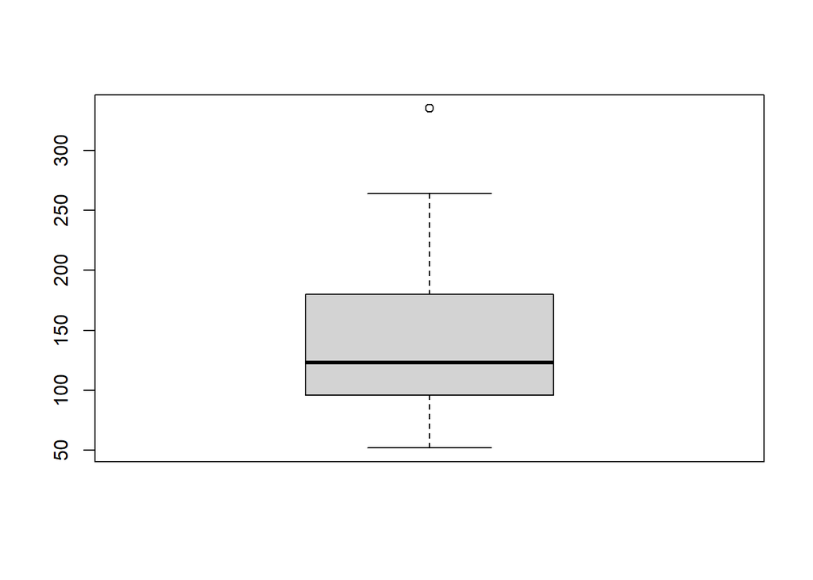

```r
# Make a boxplot
boxplot(mergedMotorCarTrendsWithoutDuplicates$HorsePower)
```

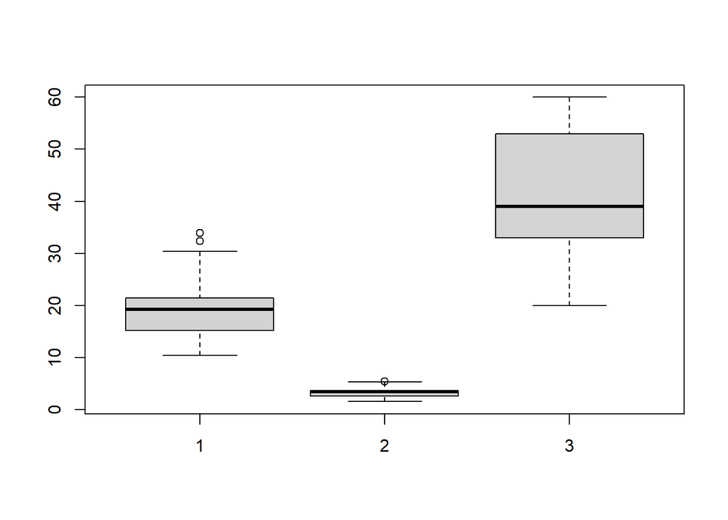

```r
# Make multiple boxplots on one axis
MilesPerGallon<- mergedMotorCarTrendsWithoutDuplicates$MilesPerGallon #Single variable to create a vector that will plot multiple boxplots
Weight<- mergedMotorCarTrendsWithoutDuplicates$Weight
AgeOfBuyer<- mergedMotorCarTrendsWithoutDuplicates$AgeOfBuyer
boxplot(MilesPerGallon, Weight, AgeOfBuyer)
```

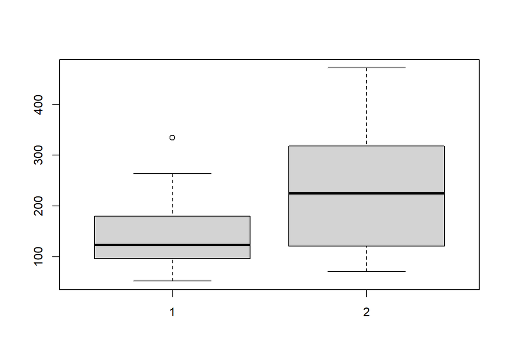

```r
# Can not always put boxplots on same axis due to the range of values
HorsePower<- mergedMotorCarTrendsWithoutDuplicates$HorsePower
Displacement<- mergedMotorCarTrendsWithoutDuplicates$Displacement
boxplot(HorsePower, Displacement)
```

```r
# Identify outlier values
boxplotStats <- boxplot.stats(mergedMotorCarTrendsWithoutDuplicates$HorsePower) #identifies outlier values

# Remove outliers from vector
HorsePower <- mergedMotorCarTrendsWithoutDuplicates$HorsePower[mergedMotorCarTrendsWithoutDuplicates$HorsePower %in% boxplotStats$out == FALSE] # Remove outliers from vector of values
HorsePower
```

```
##  [1] 110 110  93 110 175 105 245  62  95 123 123 180 180 180 205 215 230  66  52
## [20]  65  97 150 150  NA 245 175  66  91 113 264 175 109
```

```r
# Replace all outliers with NA value in data frame
mergedMotorCarTrendsWithoutDuplicates$HorsePower[mergedMotorCarTrendsWithoutDuplicates$HorsePower %in% boxplotStats$out] <- NA

# or

# Replace a single value with NA
mergedMotorCarTrendsWithoutDuplicates$HorsePower[mergedMotorCarTrendsWithoutDuplicates$HorsePower == 335] <- NA

# or

# Replace multiple values with NA value
mergedMotorCarTrendsWithoutDuplicates$HorsePower[mergedMotorCarTrendsWithoutDuplicates$HorsePower %in% c(-1,5000)] <- NA
```

### 0.5.10 Create new variable in the dataset

In R programming often we will need to calculate new information from our existing dataset. To create a new column of information from the dataset we need to name the new variable, and the action we are taking (e.g. dividing a field by 10).

```r
# Much simpler base R approach
mergedMotorCarTrendsWithoutDuplicates$MilesPerUSD <- mergedMotorCarTrendsWithoutDuplicates$MilesPerGallon / 10 #cost of gallon petrol is $10
```

### 0.5.11 Categorising data

R - Factors. Factors are the data objects which are used to categorize the data and store it as levels. They can store both strings and integers. They are useful in the columns which have a limited number of unique values.

```r
# Categorising the ages of car buyers
ageCuts <- seq(from=0, to=100, by=10)
mergedMotorCarTrendsWithoutDuplicates$AgeCategories <- cut(mergedMotorCarTrendsWithoutDuplicates$AgeOfBuyer,
                                                           breaks=ageCuts,
                                                           include.lowest=TRUE, # Include the loweest value in sequence (zero)
                                                           right=FALSE # Closed on left "[" and open on right ")" e.g. [0, 10) means values <= 0 and < 10
                                                           )
```

### 0.5.12 Calculating summary statistics to check data is cleaned

We can calculate summary statistics again to check if there are any erorrs in our data remaining before we begin the analysis.

```r
str(mergedMotorCarTrendsWithoutDuplicates)
```

```
## 'data.frame':    33 obs. of  18 variables:
##  $ IdentificationNumber: int  1 2 3 4 5 6 7 8 9 10 ...
##  $ CarModel            : chr  "Mazda " "Mazda " "Datsun " "Hornet " ...
##  $ MilesPerGallon      : num  21 21 22.8 21.4 18.7 18.1 14.3 24.4 22.8 19.2 ...
##  $ NumberOfCylinders   : int  6 6 4 6 8 6 8 4 4 6 ...
##  $ Displacement        : num  160 160 108 258 360 ...
##  $ HorsePower          : int  110 110 93 110 175 105 245 62 95 123 ...
##  $ RearAxelRatio       : num  3.9 3.9 3.85 3.08 3.15 2.76 3.21 3.69 3.92 3.92 ...
##  $ Weight              : num  2.62 2.88 2.32 3.21 3.44 ...
##  $ TimeToQuarterMile   : num  16.5 17 18.6 19.4 17 ...
##  $ EngineShape         : Factor w/ 2 levels "0","1": 1 1 2 2 1 2 1 2 2 2 ...
##  $ TransmissionType    : Factor w/ 2 levels "0","1": 2 2 2 1 1 1 1 1 1 1 ...
##  $ NumberForwardGears  : int  4 4 4 3 3 3 3 4 4 4 ...
##  $ NumberOfCarburetors : int  4 4 1 1 2 1 4 2 2 4 ...
##  $ CostOfCar           : int  21000 21000 18000 24000 27000 33000 36000 38000 42000 47000 ...
##  $ AgeOfBuyer          : int  32 37 21 21 33 39 44 42 36 39 ...
##  $ GenderOfBuyer       : chr  "Female" "Female" "Male" "Male" ...
##  $ MilesPerUSD         : num  2.1 2.1 2.28 2.14 1.87 1.81 1.43 2.44 2.28 1.92 ...
##  $ AgeCategories       : Factor w/ 10 levels "[0,10)","[10,20)",..: 4 4 3 3 4 4 5 5 4 4 ...
```

```r
summary(mergedMotorCarTrendsWithoutDuplicates)
```

```
##  IdentificationNumber   CarModel         MilesPerGallon  NumberOfCylinders
##  Min.   : 1.0         Length:33          Min.   :10.40   Min.   :4.000
##  1st Qu.: 9.0         Class :character   1st Qu.:15.20   1st Qu.:4.000
##  Median :17.0         Mode  :character   Median :19.20   Median :6.000
##  Mean   :16.7                            Mean   :19.78   Mean   :6.242
##  3rd Qu.:24.0                            3rd Qu.:21.40   3rd Qu.:8.000
##  Max.   :32.0                            Max.   :33.90   Max.   :8.000
##
##   Displacement     HorsePower    RearAxelRatio       Weight
##  Min.   : 71.1   Min.   : 52.0   Min.   :2.760   Min.   :1.513
##  1st Qu.:121.0   1st Qu.: 96.0   1st Qu.:3.080   1st Qu.:2.542
##  Median :225.0   Median :123.0   Median :3.690   Median :3.435
##  Mean   :232.9   Mean   :140.6   Mean   :3.583   Mean   :3.219
##  3rd Qu.:318.0   3rd Qu.:180.0   3rd Qu.:3.920   3rd Qu.:3.650
##  Max.   :472.0   Max.   :264.0   Max.   :4.930   Max.   :5.424
##                  NA's   :2                       NA's   :2
##  TimeToQuarterMile EngineShape TransmissionType NumberForwardGears
##  Min.   :14.50     0:19        0:20             Min.   :3.000
##  1st Qu.:16.89     1:14        1:13             1st Qu.:3.000
##  Median :17.60                                  Median :4.000
##  Mean   :17.83                                  Mean   :3.667
##  3rd Qu.:18.90                                  3rd Qu.:4.000
##  Max.   :22.90                                  Max.   :5.000
##  NA's   :2
##  NumberOfCarburetors   CostOfCar       AgeOfBuyer   GenderOfBuyer
##  Min.   :1.000       Min.   :15000   Min.   :20.0   Length:33
##  1st Qu.:2.000       1st Qu.:25500   1st Qu.:33.0   Class :character
##  Median :2.000       Median :42000   Median :39.0   Mode  :character
##  Mean   :2.788       Mean   :40097   Mean   :39.7
##  3rd Qu.:4.000       3rd Qu.:48000   3rd Qu.:53.0
##  Max.   :8.000       Max.   :85000   Max.   :60.0
##                      NA's   :2
##   MilesPerUSD    AgeCategories
##  Min.   :1.040   [30,40):10
##  1st Qu.:1.520   [20,30): 7
##  Median :1.920   [40,50): 7
##  Mean   :1.978   [50,60): 7
##  3rd Qu.:2.140   [60,70): 2
##  Max.   :3.390   [0,10) : 0
##                  (Other): 0
```

### 0.5.13 Subsetting the data

In R, we can select subsets of our data using the names or indices of rows or columns. When selecting subsets using row and column names/indices, we use the following format: `tableName[rows, columns]`

Here are some examples about how to create subsets of the `motorCarTrends` dataframe:

```r
# Select the first 3 rows of the table
first3Rows <- mergedMotorCarTrendsWithoutDuplicates[1:3, ] # Leaving the columns part blank means select all
print(first3Rows)
```

```
##   IdentificationNumber CarModel MilesPerGallon NumberOfCylinders Displacement
## 1                    1   Mazda            21.0                 6          160
## 2                    2   Mazda            21.0                 6          160
## 3                    3  Datsun            22.8                 4          108
##   HorsePower RearAxelRatio Weight TimeToQuarterMile EngineShape
## 1        110          3.90  2.620             16.46           0
## 2        110          3.90  2.875             17.02           0
## 3         93          3.85  2.320             18.61           1
##   TransmissionType NumberForwardGears NumberOfCarburetors CostOfCar AgeOfBuyer
## 1                1                  4                   4     21000         32
## 2                1                  4                   4     21000         37
## 3                1                  4                   1     18000         21
##   GenderOfBuyer MilesPerUSD AgeCategories
## 1        Female        2.10       [30,40)
## 2        Female        2.10       [30,40)
## 3          Male        2.28       [20,30)
```

```r
# Select the data for miles per gallon and horse power
milesPerGallonAndHorsePower <- mergedMotorCarTrendsWithoutDuplicates[ , c("MilesPerGallon", "HorsePower")] # Select all rows and these columns
head(milesPerGallonAndHorsePower)
```

```
##   MilesPerGallon HorsePower
## 1           21.0        110
## 2           21.0        110
## 3           22.8         93
## 4           21.4        110
## 5           18.7        175
## 6           18.1        105
```

We can use conditional statements to subset our data as well:

```r
# Select the data for automatic cars with a high horsepower
automaticCarData <- mergedMotorCarTrendsWithoutDuplicates[mergedMotorCarTrendsWithoutDuplicates$TransmissionType == 0 & mergedMotorCarTrendsWithoutDuplicates$HorsePower > 150, ]

# Take a look at this subset
prettyTable(automaticCarData)
```

|  | IdentificationNumber | CarModel | MilesPerGallon | NumberOfCylinders | Displacement | HorsePower | RearAxelRatio | Weight | TimeToQuarterMile | EngineShape | TransmissionType | NumberForwardGears | NumberOfCarburetors | CostOfCar | AgeOfBuyer | GenderOfBuyer | MilesPerUSD | AgeCategories |
| --- | --- | --- | --- | --- | --- | --- | --- | --- | --- | --- | --- | --- | --- | --- | --- | --- | --- | --- |
| 5 | 5 | Hornet | 18.70000 | 8 | 360.0 | 175 | 3.15 | 3.440 | 17.02 | 0 | 0 | 3 | 2 | 27000 | 33 | Male | 1.870000 | [30,40) |
| 7 | 7 | Ford | 14.30000 | 8 | 360.0 | 245 | 3.21 | 3.570 | 15.84 | 0 | 0 | 3 | 4 | 36000 | 44 | Female | 1.430000 | [40,50) |
| 12 | 12 | Mercedes | 16.40000 | 8 | 275.8 | 180 | 3.07 | 4.070 | 17.40 | 0 | 0 | 3 | 3 | 55000 | 47 | Male | 1.640000 | [40,50) |
| 14 | 13 | Mercedes | 19.77667 | 8 | 275.8 | 180 | 3.07 | 3.730 | 17.60 | 0 | 0 | 3 | 3 | 53000 | 53 | Female | 1.977667 | [50,60) |
| 15 | 14 | Mercedes | 15.20000 | 8 | 275.8 | 180 | 3.07 | 3.780 | 18.00 | 0 | 0 | 3 | 3 | 62000 | 56 | Female | 1.520000 | [50,60) |
| 16 | 15 | Cadillac | 10.40000 | 8 | 472.0 | 205 | 2.93 | 5.250 | 17.98 | 0 | 0 | 3 | 4 | 49000 | 38 | Female | 1.040000 | [30,40) |
| 17 | 16 | Cadillac | 10.40000 | 8 | 460.0 | 215 | 3.00 | 5.424 | 17.82 | 0 | 0 | 3 | 4 | 49000 | 44 | Male | 1.040000 | [40,50) |
| 18 | 17 | Cadillac | 14.70000 | 8 | 440.0 | 230 | 3.23 | 5.345 | 17.42 | 0 | 0 | 3 | 4 | 44000 | 44 | Male | 1.470000 | [40,50) |
| NA | NA | NA | NA | NA | NA | NA | NA | NA | NA | NA | NA | NA | NA | NA | NA | NA | NA | NA |
| 26 | 24 | Ford | 13.30000 | 8 | 350.0 | 245 | 3.73 | 3.840 | 15.41 | 0 | 0 | 3 | 4 | 63000 | 60 | Male | 1.330000 | [60,70) |
| 27 | 25 | Ford | 19.20000 | 8 | 400.0 | 175 | 3.08 | 3.845 | NA | 0 | 0 | 3 | 2 | 47000 | 55 | Female | 1.920000 | [50,60) |

## 0.6 Export cleaned dataset

```r
# Write the data to a csv file
write.csv(mergedMotorCarTrendsWithoutDuplicates, file=file.path("..", "data", "carInfo-Prices_27-05-20.csv"))
```